# R Notebook

load_data, get some statistics

[output not shown]

```
35.0 megabytes processed
```

[output not shown]

[output cut: 35 more lines]

[output not shown]

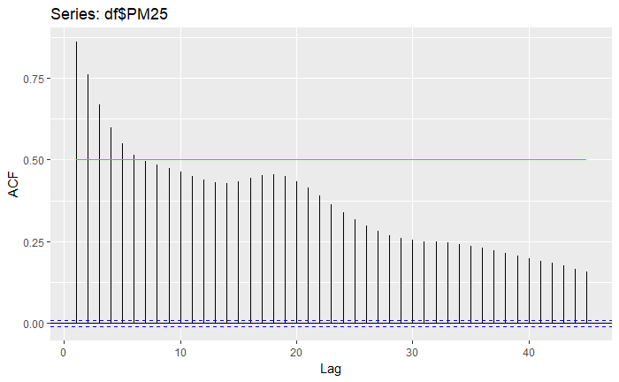

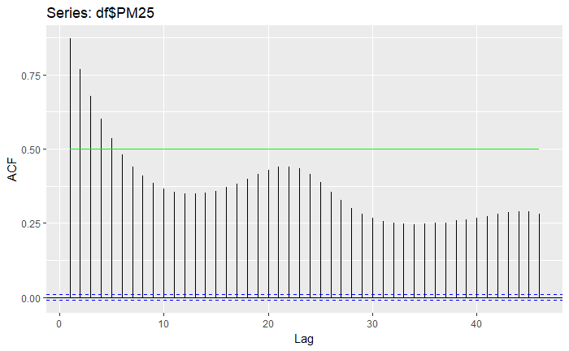

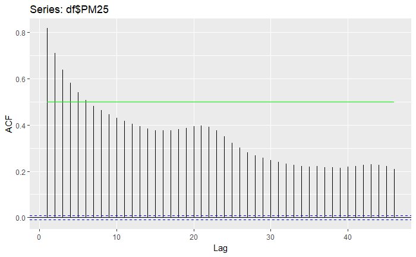

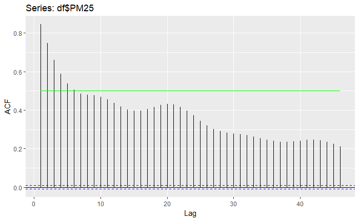

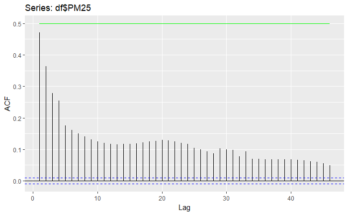

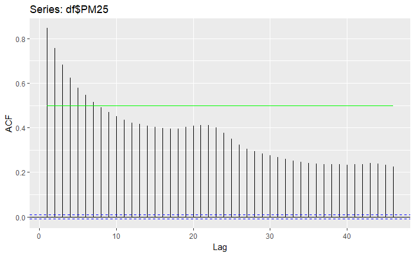

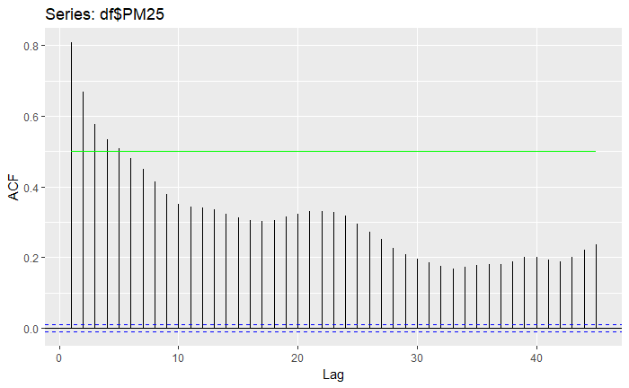

```
0 bytes processed
```

[output not shown]

Do lasso!

Do Arima: https://www.otexts.org/fpp/8/1 tsCV computes the forecast errors obtained by applying forecastfunction to subsets of the time series y using a rolling forecast origin. Value Numerical time series object containing the forecast errors as a vector (if h=1) and a matrix otherwise.

See also:http://pkg.robjhyndman.com/forecast/reference/tsCV.html#examples

A stationary time series is one whose properties do not depend on the time at which the series is observed.1 So time series with trends, or with seasonality, are not stationary - the trend and seasonality will affect the value of the time series at different times. On the other hand, a white noise series is stationary - it does not matter when you observe it, it should look much the same at any period of time.In general, a stationary time series will have no predictable patterns in the long-term. Time plots will show the series to be roughly horizontal (although some cyclic behaviour is possible) with constant variance.

As well as looking at the time plot of the data, the ACF plot is also useful for identifying non-stationary time series. For a stationary time series, the ACF will drop to zero relatively quickly, while the ACF of non-stationary data decreases slowly. Also, for non-stationary data, the value of r1r1 is often large and positive.